# Clustering Time Series

Clustering is the process of grouping like objects together so that objects within a cluster are more similar to each other than to objects of other clusters. In general, this can be performed on any kind of data (e.g. non-time series ‘static’ data), but applying it to time series involves several unique challenges. Namely, time series data often have a large degree of dependence within a single series, and time series clustering tends to be of a much higher dimension than typical static clustering.

There are three components necessary to most clustering approaches:

1. A measure of similarity or dissimilarity, i.e. a distance measure.
2. A clustering algorithm.
3. A method to evaluate clusters.

# Data

The data is collapsed by Day.

For details about data prepataion see [here](https://github.com/franziloew/mediabias/blob/master/docs/data_prep.Rmd)

```r
load(file = "../output/mediatenorCOLLAPSEDDF.Rda")

htmlTable(df.collapsed[1:20,])
```

|  | date | month | medium | p_group | category | obs | wertung | tendenz | kontext |
| --- | --- | --- | --- | --- | --- | --- | --- | --- | --- |
| 1 | 1998-02-01 | 199802 | heute | CDU/CSU | news_tv | 2 | 0 | 0 | 0 |
| 2 | 1998-02-01 | 199802 | heute | SPD | news_tv | 2 | -0.5 | 2 | 2 |
| 3 | 1998-02-01 | 199802 | heute journal | CDU/CSU | news_tv | 3 | 0 | 0 | 0 |
| 4 | 1998-02-01 | 199802 | heute journal | SPD | news_tv | 1 | 0 | 0 | 0 |
| 5 | 1998-02-01 | 199802 | RTL Aktuell | CDU/CSU | news_tv | 1 | 0 | 0 | 0 |
| 6 | 1998-02-01 | 199802 | RTL Aktuell | SPD | news_tv | 1 | 0 | 0 | 0 |
| 7 | 1998-02-01 | 199802 | Sat.1 News | SPD | news_tv | 15 | 0 | 0 | 0 |
| 8 | 1998-02-02 | 199802 | Berliner | Bündnis 90/ Die Grüne | daily_print | 9 | -0.222222222222222 | 0.888888888888889 | 0.888888888888889 |
| 9 | 1998-02-02 | 199802 | Berliner | CDU/CSU | daily_print | 13 | 0 | 1.76923076923077 | 1.76923076923077 |
| 10 | 1998-02-02 | 199802 | Berliner | FDP | daily_print | 4 | 0 | 2.25 | 2.25 |
| 11 | 1998-02-02 | 199802 | Berliner | Linke/PDS/WASG | daily_print | 8 | 0.25 | 1 | 1 |
| 12 | 1998-02-02 | 199802 | Berliner | SPD | daily_print | 91 | 0.010989010989011 | 0.923076923076923 | 0.934065934065934 |
| 13 | 1998-02-02 | 199802 | Bild | Bündnis 90/ Die Grüne | daily_print | 1 | 0 | 0 | 0 |
| 14 | 1998-02-02 | 199802 | Bild | CDU/CSU | daily_print | 1 | 0 | 0 | 0 |
| 15 | 1998-02-02 | 199802 | Bild | FDP | daily_print | 4 | 0 | 0 | 0 |
| 16 | 1998-02-02 | 199802 | Bild | SPD | daily_print | 18 | 0 | 0 | 0.833333333333333 |
| 17 | 1998-02-02 | 199802 | Die Welt | Bündnis 90/ Die Grüne | daily_print | 11 | 0 | 0 | 0 |
| 18 | 1998-02-02 | 199802 | Die Welt | CDU/CSU | daily_print | 19 | -0.157894736842105 | 0.421052631578947 | 0.789473684210526 |
| 19 | 1998-02-02 | 199802 | Die Welt | FDP | daily_print | 1 | -1 | 0 | 4 |
| 20 | 1998-02-02 | 199802 | Die Welt | Linke/PDS/WASG | daily_print | 3 | -0.666666666666667 | 1.33333333333333 | 2.66666666666667 |

## Subset

To test the approach, I subset the data to:

```
* Timespan: Jan 2003 - Jan 2004

* Category: Tageszeitungen, TV-Nachrichten

* Time Series: CDU/CSU
```

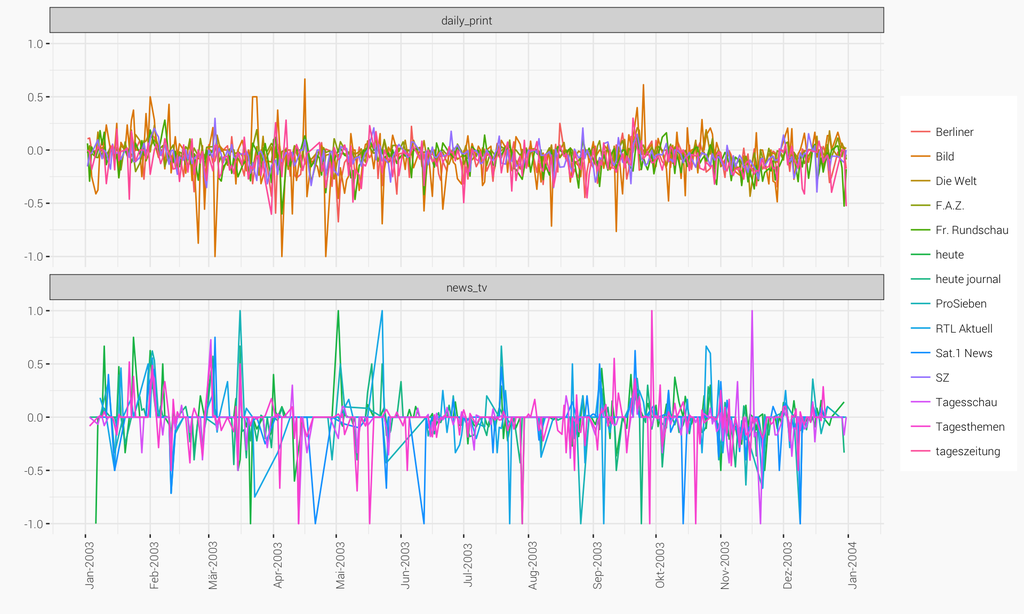

```r
df.collapsed %>%
  filter(category %in% c("daily_print", "news_tv")) %>%
  mutate(medium = as.character(medium)) %>%
  filter(p_group == "CDU/CSU") %>%
  filter(date > "2003-01-01" &
           date < "2004-01-01") %>%
  select(date, wertung, medium, category) -> daily.print

ggplot(daily.print, aes(date, wertung, color = medium)) +
  geom_line() + labs(x="", y="", color="") +
  scale_x_date(breaks = date_breaks("1 month"),
               labels=date_format("%b-%Y", tz="CET")) +
  facet_wrap(~category, ncol = 1) +
  theme(axis.text.x = element_text(angle = 90))
```

# Similarity/Distance Measure

Clustering involves grouping objects together through a measure of similarity. This need not always be a distance, strictly speaking (e.g. both similarity measures defined below do not satisfy the triangle inequality), so long as it can be used to create a pairwise similarity matrix between all objects. A naive approach which often performs decently in practice is to simply use Euclidean (or L1, etc.) distance.

Many similarity measures can be found in the literature and can be mixed and matched with different clustering algorithms. An overview is given in [Aghabozorgi (2015)](https://www.sciencedirect.com/science/article/pii/S0306437915000733#t0020)

### DTW

Dynamic Time Warping (DTW) can be thought of as an alignment algorithm. The basic idea is to match the shapes of the time series while allowing for different time speed by computing an optimum ‘warping curve’. It is slower and more computationally intensive than Euclidean distance but tends to be more robust. It is most easily understood visually.

The computed distance between the two series is:

```r
library("dtw")

ref <- ts(daily.print %>%
            filter(medium == "Bild") %>% select(wertung))
test <- ts(daily.print %>%
            filter(medium == "Die Welt") %>% select(wertung))

alignment <- dtw(test,ref,k=T)
alignment$distance
```

[output not shown]

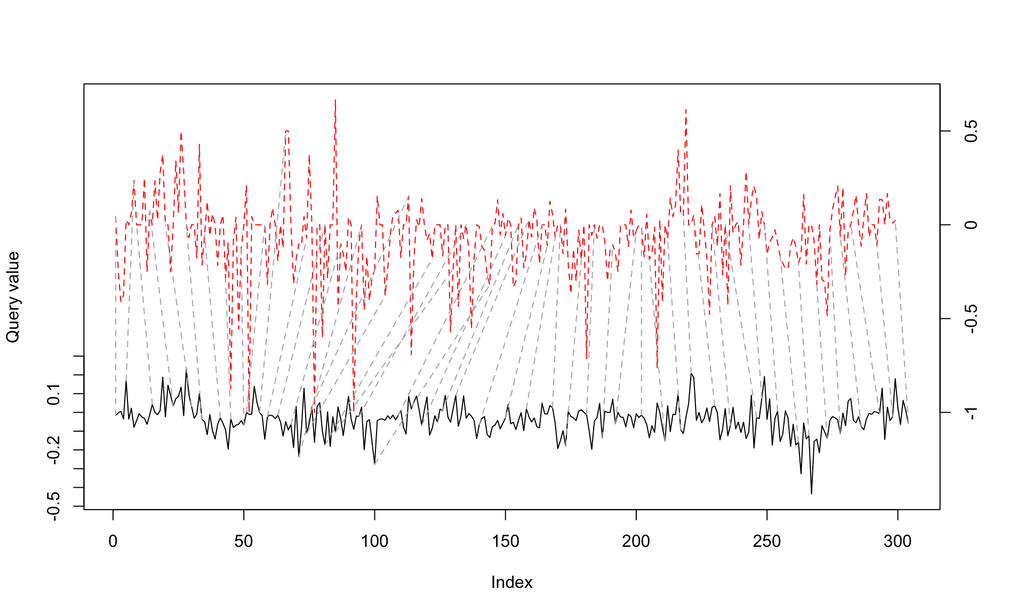

```r
plot(alignment,type="two",off=1,
     match.lty=2,match.indices=50)
```

Our ultimate objective is to cluster different mediums based on their similarities in the valuation of CDU/CSU over time. So we need to produce a distance matrix where each cell contains the distance between a pair of medium valuation time series.

```r
# Split data into list by medium
ds <- split(daily.print, daily.print$medium)

# Use expand.grid to make all combinations of names and values
names <- expand.grid(unique(daily.print$medium), unique(daily.print$medium))
values <- expand.grid(ds,ds)

# purrr:map_dbl iterates through all row-combinations of Values and returns a vector of doubles
Dist <- map_dbl(1:nrow(values), ~dtw(x = values[.x,]$Var1[[1]]$wertung,
                                     y = values[.x,]$Var2[[1]]$wertung)$distance)

# Bind answer to names
ans <- names %>% mutate(distance = Dist)

ans %>%
  mutate(distance = round(distance,2)) %>%
  spread(Var2, distance) %>%
  htmlTable::htmlTable()
```

|  | Var1 | Berliner | Die Welt | F.A.Z. | Fr. Rundschau | SZ | tageszeitung | Bild | heute journal | Tagesschau | Tagesthemen | heute | ProSieben | Sat.1 News | RTL Aktuell |
| --- | --- | --- | --- | --- | --- | --- | --- | --- | --- | --- | --- | --- | --- | --- | --- |
| 1 | Berliner | 0 | 42.14 | 27.78 | 27.51 | 28.76 | 36.29 | 31.02 | 33.22 | 34.33 | 33.75 | 27.13 | 29.67 | 37.36 | 29.42 |
| 2 | Die Welt | 42.14 | 0 | 41.5 | 41.16 | 41.47 | 40.64 | 39.58 | 38.57 | 39.17 | 37.69 | 40.89 | 37.69 | 41.03 | 42.97 |
| 3 | F.A.Z. | 27.78 | 41.5 | 0 | 17.94 | 24.68 | 31.56 | 26.59 | 26.12 | 29.72 | 27.46 | 21.42 | 26.14 | 34.68 | 27.53 |
| 4 | Fr. Rundschau | 27.51 | 41.16 | 17.94 | 0 | 25.68 | 30.71 | 26.18 | 24.25 | 28.11 | 26.2 | 20.57 | 24.56 | 33.65 | 27.89 |
| 5 | SZ | 28.76 | 41.47 | 24.68 | 25.68 | 0 | 36.71 | 30.77 | 31.94 | 33.47 | 32.72 | 25.64 | 29.39 | 38.49 | 27.97 |
| 6 | tageszeitung | 36.29 | 40.64 | 31.56 | 30.71 | 36.71 | 0 | 27.53 | 24.46 | 22.94 | 24 | 31.64 | 26.04 | 29.76 | 37.56 |
| 7 | Bild | 31.02 | 39.58 | 26.59 | 26.18 | 30.77 | 27.53 | 0 | 21.76 | 24.85 | 23.22 | 27.44 | 24.08 | 30.49 | 31.78 |
| 8 | heute journal | 33.22 | 38.57 | 26.12 | 24.25 | 31.94 | 24.46 | 21.76 | 0 | 17.72 | 13 | 27.32 | 20.01 | 27.55 | 33.64 |
| 9 | Tagesschau | 34.33 | 39.17 | 29.72 | 28.11 | 33.47 | 22.94 | 24.85 | 17.72 | 0 | 18.89 | 29.67 | 23.22 | 28.38 | 36.1 |
| 10 | Tagesthemen | 33.75 | 37.69 | 27.46 | 26.2 | 32.72 | 24 | 23.22 | 13 | 18.89 | 0 | 28.73 | 21.49 | 25.78 | 35.6 |
| 11 | heute | 27.13 | 40.89 | 21.42 | 20.57 | 25.64 | 31.64 | 27.44 | 27.32 | 29.67 | 28.73 | 0 | 26.08 | 35.1 | 27.41 |
| 12 | ProSieben | 29.67 | 37.69 | 26.14 | 24.56 | 29.39 | 26.04 | 24.08 | 20.01 | 23.22 | 21.49 | 26.08 | 0 | 29.39 | 31.23 |
| 13 | Sat.1 News | 37.36 | 41.03 | 34.68 | 33.65 | 38.49 | 29.76 | 30.49 | 27.55 | 28.38 | 25.78 | 35.1 | 29.39 | 0 | 39.66 |
| 14 | RTL Aktuell | 29.42 | 42.97 | 27.53 | 27.89 | 27.97 | 37.56 | 31.78 | 33.64 | 36.1 | 35.6 | 27.41 | 31.23 | 39.66 | 0 |

## Plot Results

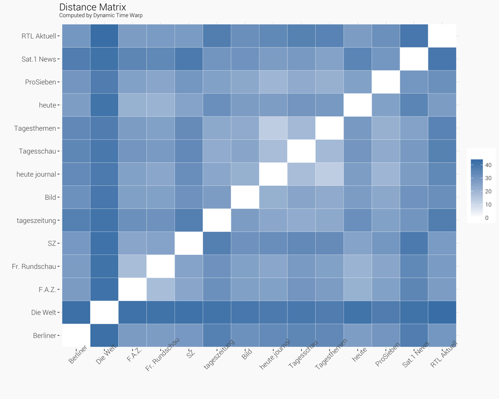

```r
ggplot(ans, aes(Var1, Var2)) +
  geom_tile(aes(fill=distance), color = "white") +
  scale_fill_gradient(low = "white", high = "steelblue") +
  labs(x="",y="",fill="",
       title="Distance Matrix",
       subtitle = "Computed by Dynamic Time Warp") +
  theme(axis.text.x = element_text(angle=45),
        axis.text = element_text(size = 10))
```

# K-medoids clustering

K-medoids is the better choice after DTW (uses DTW-medoid for finding the cluster center).

As DTW is not minimized by the mean, k-means may not converge and even if it converges it will not yield a very good result. The mean is an least-squares estimator on the coordinates. It minimizes variance, not arbitrary distances, and k-means is designed for minimizing variance, not arbitrary distances.

```r
library(cluster)
library(factoextra)
```

```r
ans %>%
  spread(Var2, distance) -> ans.wide

m.ans <- as.matrix(ans.wide %>% select(-Var1))
rownames(m.ans) <- ans.wide$Var1
```

## Results (K = 3)

```r
k = 3
pam.k <- pam(m.ans, k = k)
pam.k
```

```
## Medoids:
##             ID Berliner Die Welt   F.A.Z. Fr. Rundschau       SZ
## F.A.Z.       3 27.77982 41.50414  0.00000      17.93783 24.68319
## Die Welt     2 42.13949  0.00000 41.50414      41.16401 41.46655
## Tagesthemen 10 33.74965 37.68546 27.46236      26.19568 32.72373
##             tageszeitung     Bild heute journal Tagesschau Tagesthemen
## F.A.Z.          31.55834 26.59099      26.12000   29.71619    27.46236
## Die Welt        40.63801 39.57865      38.56558   39.16638    37.68546
## Tagesthemen     23.99774 23.21979      13.00202   18.88712     0.00000
##                heute ProSieben Sat.1 News RTL Aktuell
## F.A.Z.      21.41721  26.14310   34.67701    27.52536
## Die Welt    40.88548  37.69125   41.02852    42.97433
## Tagesthemen 28.72624  21.49143   25.77981    35.59648
## Clustering vector:
##      Berliner      Die Welt        F.A.Z. Fr. Rundschau            SZ
##             1             2             1             1             1
##  tageszeitung          Bild heute journal    Tagesschau   Tagesthemen
##             3             3             3             3             3
##         heute     ProSieben    Sat.1 News   RTL Aktuell
##             1             3             3             1
## Objective function:
##    build     swap
## 28.76662 27.05543
##
## Available components:
##  [1] "medoids"    "id.med"     "clustering" "objective"  "isolation"
##  [6] "clusinfo"   "silinfo"    "diss"       "call"       "data"
```

```r
m.ans %>%
  as_tibble() %>%
  mutate(cluster = pam.k$clustering,
         medium = ans.wide$Var1) %>%
  select(medium, cluster) %>%
  htmlTable()
```

|  | medium | cluster |
| --- | --- | --- |
| 1 | Berliner | 1 |
| 2 | Die Welt | 2 |
| 3 | F.A.Z. | 1 |
| 4 | Fr. Rundschau | 1 |
| 5 | SZ | 1 |
| 6 | tageszeitung | 3 |
| 7 | Bild | 3 |
| 8 | heute journal | 3 |
| 9 | Tagesschau | 3 |
| 10 | Tagesthemen | 3 |
| 11 | heute | 1 |
| 12 | ProSieben | 3 |
| 13 | Sat.1 News | 3 |
| 14 | RTL Aktuell | 1 |

### Plot Results

- The default level of the concentration ellipse is 0.95.

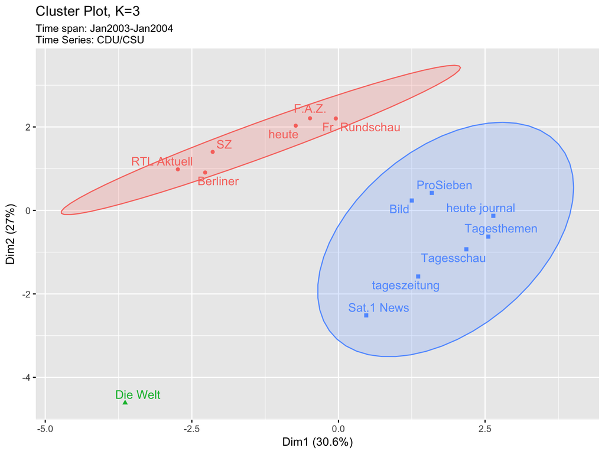

```r
fviz_cluster(pam.k,
             ellipse.type = "t", # Concentration ellipse
             repel = T,
             title = paste0("Cluster Plot, K=",k),
             subtitle = "Time span: Jan2003-Jan2004\nTime Series: CDU/CSU"
             ) +
  theme(legend.position = "none")
```

### With K = 4

```
## Too few points to calculate an ellipse
## Too few points to calculate an ellipse
```

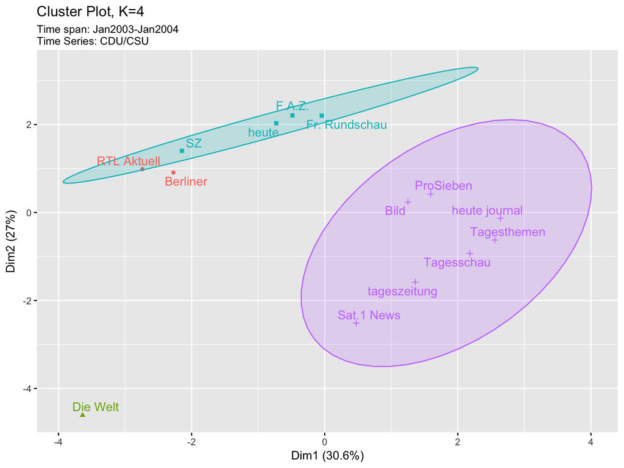

```r
k = 4
pam.k <- pam(m.ans, k = k)

fviz_cluster(pam.k,
             ellipse.type = "t", # Concentration ellipse
             repel = T,
             title = paste0("Cluster Plot, K=",k),
             subtitle = "Time span: Jan2003-Jan2004\nTime Series: CDU/CSU"
             ) +
  theme(legend.position = "none")
```